# 9 Geospatial joins

Another important tool in geospatial data science is the **geospatial join**. We will introduce the concept with a practical example, and will explain how it is related to the standard join of two tables.

## 9.1 Motivation

The split-apply-combine pattern that we learned in the previous chapter requires a **single** geotable with all the relevant information in it. However, many questions in geospatial data science can only be answered with information that is spread across **multiple** geotables. Hence, the need to **join** these geotables before attempting to `@groupby`, `@transform` and `@combine` the information.

Let’s consider a simple example where we are given two geotables, one containing people who shared their latitude and longitude coordinates:

```julia
table = (
  NAME=["John", "Mary", "Paul", "Anne", "Kate"],
  AGE=[34.0, 12.0, 23.0, 39.0, 28.0]u"yr",
  HEIGHT=[1.78, 1.56, 1.70, 1.80, 1.72]u"m",
  LATITUDE=[-22.96710361241228, 37.42773662442142, -27.486220858775997, 39.90358408375064, -3.847311538763359],
  LONGITUDE=[-43.17891118844475, -122.17007072663823, 153.04380578036657, 116.40764745941036, -32.411372812211226]
)

people = georef(table, ("LONGITUDE", "LATITUDE")) |> Proj(PlateCarree)
```

| 5×4 GeoTable over 5 PointSet NAME Categorical [NoUnits] | 5×4 GeoTable over 5 PointSet AGE Continuous [yr] | 5×4 GeoTable over 5 PointSet HEIGHT Continuous [m] | 5×4 GeoTable over 5 PointSet geometry Point 🖈 PlateCarree{WGS84Latest} |
| --- | --- | --- | --- |
| John | 34.0 yr | 1.78 m | (x: -4.80665e6 m, y: -2.55669e6 m) |
| Mary | 12.0 yr | 1.56 m | (x: -1.35999e7 m, y: 4.16644e6 m) |
| Paul | 23.0 yr | 1.7 m | (x: 1.70368e7 m, y: -3.05975e6 m) |
| Anne | 39.0 yr | 1.8 m | (x: 1.29584e7 m, y: 4.44205e6 m) |
| Kate | 28.0 yr | 1.72 m | (x: -3.60802e6 m, y: -4.28281e5 m) |

And another containing countries in the world according to the [Natural Earth](https://www.naturalearthdata.com) project:

```julia
using GeoIO

countries = GeoIO.load("data/countries.geojson") |> Proj(PlateCarree)
```

167 rows omitted

| 177×3 GeoTable over 177 GeometrySet COUNTRY Categorical [NoUnits] | 177×3 GeoTable over 177 GeometrySet REGION Categorical [NoUnits] | 177×3 GeoTable over 177 GeometrySet geometry MultiPolygon 🖈 PlateCarree{WGS84Latest} |
| --- | --- | --- |
| Fiji | Melanesia | Multi(3×Pgon) |
| Tanzania | Eastern Africa | Multi(1×Pgon) |
| W. Sahara | Northern Africa | Multi(1×Pgon) |
| Canada | Northern America | Multi(30×Pgon) |
| United States of America | Northern America | Multi(10×Pgon) |
| Kazakhstan | Central Asia | Multi(1×Pgon) |
| Uzbekistan | Central Asia | Multi(1×Pgon) |
| Papua New Guinea | Melanesia | Multi(4×Pgon) |
| Indonesia | South-Eastern Asia | Multi(13×Pgon) |
| Argentina | South America | Multi(2×Pgon) |
| ⋮ | ⋮ | ⋮ |

**Note**

The `georef` function has a method that accepts the names of columns with geospatial coordinates. In this example, the `table` already has the `LATITUDE` and `LONGITUDE` coordinates, which we project to a `PlateCarree` CRS as discussed in the chapter Map projections.

Let’s visualize the geometries of these two geotables:

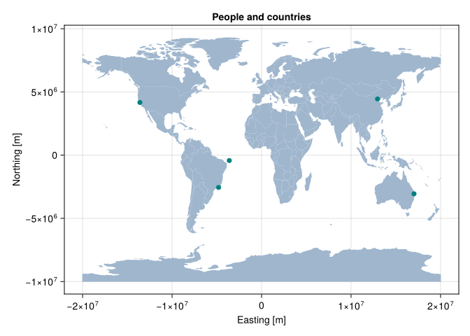

```julia
fig = Mke.Figure()
ax = Mke.Axis(fig[1,1], title = "People and countries",
              xlabel = "Easting [m]", ylabel = "Northing [m]")
viz!(countries.geometry)
viz!(people.geometry, color = "teal", size = 10)
fig
```

Our goal in this example is to attach the “COUNTRY” and “REGION” information to each individual based on their location, represented as a point. In other words, we want to find the `countries` that **contain the location**, and then copy the columns to the `people`.

## 9.2 Joining geotables

The `geojoin` function can be used to join two geotables using a **geometric predicate** function:

```julia
geojoin(people, countries, pred = ∈)
```

| 5×6 GeoTable over 5 PointSet NAME Categorical [NoUnits] | 5×6 GeoTable over 5 PointSet AGE Continuous [yr] | 5×6 GeoTable over 5 PointSet HEIGHT Continuous [m] | 5×6 GeoTable over 5 PointSet COUNTRY Categorical [NoUnits] | 5×6 GeoTable over 5 PointSet REGION Categorical [NoUnits] | 5×6 GeoTable over 5 PointSet geometry Point 🖈 PlateCarree{WGS84Latest} |
| --- | --- | --- | --- | --- | --- |
| John | 34.0 yr | 1.78 m | Brazil | South America | (x: -4.80665e6 m, y: -2.55669e6 m) |
| Mary | 12.0 yr | 1.56 m | United States of America | Northern America | (x: -1.35999e7 m, y: 4.16644e6 m) |
| Paul | 23.0 yr | 1.7 m | Australia | Australia and New Zealand | (x: 1.70368e7 m, y: -3.05975e6 m) |
| Anne | 39.0 yr | 1.8 m | China | Eastern Asia | (x: 1.29584e7 m, y: 4.44205e6 m) |
| Kate | 28.0 yr | 1.72 m | missing | missing | (x: -3.60802e6 m, y: -4.28281e5 m) |

In the example above, we used the `∈` predicate to check if a `Point` in the `people` geotable is in a `MultiPolygon` in the `countries` geotable. The default predicate in `geojoin` is the `intersects` function that we covered in previous chapters.

Notice that Kate’s “COUNTRY” and “REGION” are `missing`. That is because Kate lives in the [Fernando de Noronha](https://en.wikipedia.org/wiki/Fernando_de_Noronha) island, which is not present in the `countries` geotable. To retain just those people for which the geometric predicate evaluates `true`, we can use a different `kind` of `geojoin` known as `:inner`:

```julia
geojoin(people, countries, kind = :inner)
```

| 4×6 GeoTable over 4 view(::PointSet, [1, 2, 3, 4]) NAME Categorical [NoUnits] | 4×6 GeoTable over 4 view(::PointSet, [1, 2, 3, 4]) AGE Continuous [yr] | 4×6 GeoTable over 4 view(::PointSet, [1, 2, 3, 4]) HEIGHT Continuous [m] | 4×6 GeoTable over 4 view(::PointSet, [1, 2, 3, 4]) COUNTRY Categorical [NoUnits] | 4×6 GeoTable over 4 view(::PointSet, [1, 2, 3, 4]) REGION Categorical [NoUnits] | 4×6 GeoTable over 4 view(::PointSet, [1, 2, 3, 4]) geometry Point 🖈 PlateCarree{WGS84Latest} |
| --- | --- | --- | --- | --- | --- |
| John | 34.0 yr | 1.78 m | Brazil | South America | (x: -4.80665e6 m, y: -2.55669e6 m) |
| Mary | 12.0 yr | 1.56 m | United States of America | Northern America | (x: -1.35999e7 m, y: 4.16644e6 m) |
| Paul | 23.0 yr | 1.7 m | Australia | Australia and New Zealand | (x: 1.70368e7 m, y: -3.05975e6 m) |
| Anne | 39.0 yr | 1.8 m | China | Eastern Asia | (x: 1.29584e7 m, y: 4.44205e6 m) |

By default, the `:left` kind is used. Like in standard join, the `geojoin` is not commutative. If we swap the order of the geotables, the result will be different:

```julia
geojoin(countries, people, kind = :inner)
```

| 4×6 GeoTable over 4 view(::GeometrySet, [5, 30, 138, 140]) COUNTRY Categorical [NoUnits] | 4×6 GeoTable over 4 view(::GeometrySet, [5, 30, 138, 140]) REGION Categorical [NoUnits] | 4×6 GeoTable over 4 view(::GeometrySet, [5, 30, 138, 140]) NAME Categorical [NoUnits] | 4×6 GeoTable over 4 view(::GeometrySet, [5, 30, 138, 140]) AGE Continuous [yr] | 4×6 GeoTable over 4 view(::GeometrySet, [5, 30, 138, 140]) HEIGHT Continuous [m] | 4×6 GeoTable over 4 view(::GeometrySet, [5, 30, 138, 140]) geometry MultiPolygon 🖈 PlateCarree{WGS84Latest} |
| --- | --- | --- | --- | --- | --- |
| United States of America | Northern America | Mary | 12.0 yr | 1.56 m | Multi(10×Pgon) |
| Brazil | South America | John | 34.0 yr | 1.78 m | Multi(1×Pgon) |
| Australia | Australia and New Zealand | Paul | 23.0 yr | 1.7 m | Multi(2×Pgon) |
| China | Eastern Asia | Anne | 39.0 yr | 1.8 m | Multi(2×Pgon) |

To learn about the different `kind`s of join, check DataFrames.jl’s [documentation on joins](https://dataframes.juliadata.org/stable/man/joins).

**Note**

In database-style join, the predicate function `isequal` is applied to arbitrary columns of tables. In `geojoin`, **geometric predicate** functions are applied to the `geometry` column of geotables.

The `tablejoin` function can be used for database-style join between a geotable and a simple table (e.g., `DataFrame`). The result will be a new geotable over a subset of geometries from the first argument. Please check the documentation for more details.

**NoteTip for all users**

Besides `geojoin`, the framework also provides vertical and horizontal concatenation of geotables. Vertical concatenation is achieved with `vcat` as follows:

```julia
gt1 = georef((a=[1,2,3], b=[4,5,6]))
gt2 = georef((b=[4,5,6], c=[7,8,9]))

vcat(gt1, gt2)
```

| 6×4 GeoTable over 6 GeometrySet a Categorical [NoUnits] | 6×4 GeoTable over 6 GeometrySet b Categorical [NoUnits] | 6×4 GeoTable over 6 GeometrySet c Categorical [NoUnits] | 6×4 GeoTable over 6 GeometrySet geometry Segment 🖈 Cartesian{NoDatum} |
| --- | --- | --- | --- |
| 1 | 4 | missing | Segment((x: 0.0 m), (x: 1.0 m)) |
| 2 | 5 | missing | Segment((x: 1.0 m), (x: 2.0 m)) |
| 3 | 6 | missing | Segment((x: 2.0 m), (x: 3.0 m)) |
| missing | 4 | 7 | Segment((x: 0.0 m), (x: 1.0 m)) |
| missing | 5 | 8 | Segment((x: 1.0 m), (x: 2.0 m)) |
| missing | 6 | 9 | Segment((x: 2.0 m), (x: 3.0 m)) |

All columns are preserved by default, which corresponds to the option `kind = :union`. Absent columns are filled with `missing` values. The option `kind = :intersect` can be used to retain only the columns that are present in all geotables:

```julia
vcat(gt1, gt2, kind = :intersect)
```

| 6×2 GeoTable over 6 GeometrySet b Categorical [NoUnits] | 6×2 GeoTable over 6 GeometrySet geometry Segment 🖈 Cartesian{NoDatum} |
| --- | --- |
| 4 | Segment((x: 0.0 m), (x: 1.0 m)) |
| 5 | Segment((x: 1.0 m), (x: 2.0 m)) |
| 6 | Segment((x: 2.0 m), (x: 3.0 m)) |
| 4 | Segment((x: 0.0 m), (x: 1.0 m)) |
| 5 | Segment((x: 1.0 m), (x: 2.0 m)) |
| 6 | Segment((x: 2.0 m), (x: 3.0 m)) |

Horizontal concatenation is achieved with `hcat` as follows:

```julia
hcat(gt1, gt2)
```

| 3×5 GeoTable over 3 CartesianGrid a Categorical [NoUnits] | 3×5 GeoTable over 3 CartesianGrid b Categorical [NoUnits] | 3×5 GeoTable over 3 CartesianGrid b_ Categorical [NoUnits] | 3×5 GeoTable over 3 CartesianGrid c Categorical [NoUnits] | 3×5 GeoTable over 3 CartesianGrid geometry Segment 🖈 Cartesian{NoDatum} |
| --- | --- | --- | --- | --- |
| 1 | 4 | 4 | 7 | Segment((x: 0.0 m), (x: 1.0 m)) |
| 2 | 5 | 5 | 8 | Segment((x: 1.0 m), (x: 2.0 m)) |
| 3 | 6 | 6 | 9 | Segment((x: 2.0 m), (x: 3.0 m)) |

Unique column names are produced with underscore suffixes whenever a column appears in multiple geotables. Julia provides convenient syntax for `vcat` and `hcat`:

```julia
[gt1
 gt2]
```

| 6×4 GeoTable over 6 GeometrySet a Categorical [NoUnits] | 6×4 GeoTable over 6 GeometrySet b Categorical [NoUnits] | 6×4 GeoTable over 6 GeometrySet c Categorical [NoUnits] | 6×4 GeoTable over 6 GeometrySet geometry Segment 🖈 Cartesian{NoDatum} |
| --- | --- | --- | --- |
| 1 | 4 | missing | Segment((x: 0.0 m), (x: 1.0 m)) |
| 2 | 5 | missing | Segment((x: 1.0 m), (x: 2.0 m)) |
| 3 | 6 | missing | Segment((x: 2.0 m), (x: 3.0 m)) |
| missing | 4 | 7 | Segment((x: 0.0 m), (x: 1.0 m)) |
| missing | 5 | 8 | Segment((x: 1.0 m), (x: 2.0 m)) |
| missing | 6 | 9 | Segment((x: 2.0 m), (x: 3.0 m)) |

```julia
[gt1 gt2]
```

| 3×5 GeoTable over 3 CartesianGrid a Categorical [NoUnits] | 3×5 GeoTable over 3 CartesianGrid b Categorical [NoUnits] | 3×5 GeoTable over 3 CartesianGrid b_ Categorical [NoUnits] | 3×5 GeoTable over 3 CartesianGrid c Categorical [NoUnits] | 3×5 GeoTable over 3 CartesianGrid geometry Segment 🖈 Cartesian{NoDatum} |
| --- | --- | --- | --- | --- |
| 1 | 4 | 4 | 7 | Segment((x: 0.0 m), (x: 1.0 m)) |
| 2 | 5 | 5 | 8 | Segment((x: 1.0 m), (x: 2.0 m)) |
| 3 | 6 | 6 | 9 | Segment((x: 2.0 m), (x: 3.0 m)) |

## 9.3 Common predicates

In geospatial data science, the most common geometric predicates used in `geojoin` are `∈`, `⊆`, `==`, `≈` and `intersects` as illustrated in Table 9.1. Specific applications may require custom predicates, which can be easily defined in pure Julia with the Meshes.jl module. For example, it is sometimes convenient to define geometric predicates in terms of a distance and a threshold:

```julia
pred(g1, g2) = EuclideanDistance()(centroid(g1), centroid(g2)) ≤ 1500u"km"

geojoin(people, countries, kind = :inner, pred = pred)
```

| 2×6 GeoTable over 2 view(::PointSet, [2, 4]) NAME Categorical [NoUnits] | 2×6 GeoTable over 2 view(::PointSet, [2, 4]) AGE Continuous [yr] | 2×6 GeoTable over 2 view(::PointSet, [2, 4]) HEIGHT Continuous [m] | 2×6 GeoTable over 2 view(::PointSet, [2, 4]) COUNTRY Categorical [NoUnits] | 2×6 GeoTable over 2 view(::PointSet, [2, 4]) REGION Categorical [NoUnits] | 2×6 GeoTable over 2 view(::PointSet, [2, 4]) geometry Point 🖈 PlateCarree{WGS84Latest} |
| --- | --- | --- | --- | --- | --- |
| Mary | 12.0 yr | 1.56 m | United States of America | Northern America | (x: -1.35999e7 m, y: 4.16644e6 m) |
| Anne | 39.0 yr | 1.8 m | South Korea | Eastern Asia | (x: 1.29584e7 m, y: 4.44205e6 m) |

Table 9.1: Common geometric predicates in geospatial join

| PREDICATE | EXAMPLE |
| --- | --- |
| ∈ |  |
| ⊆ |  |
| == |  |
| ≈ |  |
| intersects |  |

## 9.4 Multiple matches

Sometimes the predicate function will evaluate `true` for multiple rows of the geotables. In this case, we need to decide which value will be copied to the resulting geotable. The `geojoin` accepts reduction functions for each column. For example, suppose that Kate decided to move to the continent:

```julia
table = (
  NAME=["John", "Mary", "Paul", "Anne", "Kate"],
  AGE=[34.0, 12.0, 23.0, 39.0, 28.0]u"yr",
  HEIGHT=[1.78, 1.56, 1.70, 1.80, 1.72]u"m",
  LATITUDE=[-22.96710361241228, 37.42773662442142, -27.486220858775997, 39.90358408375064, -9.66628224039543],
  LONGITUDE=[-43.17891118844475, -122.17007072663823, 153.04380578036657, 116.40764745941036, -35.71261407423411]
)

people = georef(table, ("LONGITUDE", "LATITUDE")) |> Proj(PlateCarree)
```

| 5×4 GeoTable over 5 PointSet NAME Categorical [NoUnits] | 5×4 GeoTable over 5 PointSet AGE Continuous [yr] | 5×4 GeoTable over 5 PointSet HEIGHT Continuous [m] | 5×4 GeoTable over 5 PointSet geometry Point 🖈 PlateCarree{WGS84Latest} |
| --- | --- | --- | --- |
| John | 34.0 yr | 1.78 m | (x: -4.80665e6 m, y: -2.55669e6 m) |
| Mary | 12.0 yr | 1.56 m | (x: -1.35999e7 m, y: 4.16644e6 m) |
| Paul | 23.0 yr | 1.7 m | (x: 1.70368e7 m, y: -3.05975e6 m) |
| Anne | 39.0 yr | 1.8 m | (x: 1.29584e7 m, y: 4.44205e6 m) |
| Kate | 28.0 yr | 1.72 m | (x: -3.97551e6 m, y: -1.07605e6 m) |

Now, both John and Kate live in Brazil according the `countries` geotable:

```julia
geojoin(people, countries)
```

| 5×6 GeoTable over 5 PointSet NAME Categorical [NoUnits] | 5×6 GeoTable over 5 PointSet AGE Continuous [yr] | 5×6 GeoTable over 5 PointSet HEIGHT Continuous [m] | 5×6 GeoTable over 5 PointSet COUNTRY Categorical [NoUnits] | 5×6 GeoTable over 5 PointSet REGION Categorical [NoUnits] | 5×6 GeoTable over 5 PointSet geometry Point 🖈 PlateCarree{WGS84Latest} |
| --- | --- | --- | --- | --- | --- |
| John | 34.0 yr | 1.78 m | Brazil | South America | (x: -4.80665e6 m, y: -2.55669e6 m) |
| Mary | 12.0 yr | 1.56 m | United States of America | Northern America | (x: -1.35999e7 m, y: 4.16644e6 m) |
| Paul | 23.0 yr | 1.7 m | Australia | Australia and New Zealand | (x: 1.70368e7 m, y: -3.05975e6 m) |
| Anne | 39.0 yr | 1.8 m | China | Eastern Asia | (x: 1.29584e7 m, y: 4.44205e6 m) |
| Kate | 28.0 yr | 1.72 m | Brazil | South America | (x: -3.97551e6 m, y: -1.07605e6 m) |

If we swap the order of the geotables in the `geojoin`, we need to decide how to reduce the multiple values of “NAME”, “AGE” and “HEIGHT” in the resulting geotable. By default, the `mean` function is used to reduce `Continuous` variables, and the `first` function is used otherwise:

```julia
geojoin(countries, people, kind = :inner)
```

| 4×6 GeoTable over 4 view(::GeometrySet, [5, 30, 138, 140]) COUNTRY Categorical [NoUnits] | 4×6 GeoTable over 4 view(::GeometrySet, [5, 30, 138, 140]) REGION Categorical [NoUnits] | 4×6 GeoTable over 4 view(::GeometrySet, [5, 30, 138, 140]) NAME Categorical [NoUnits] | 4×6 GeoTable over 4 view(::GeometrySet, [5, 30, 138, 140]) AGE Continuous [yr] | 4×6 GeoTable over 4 view(::GeometrySet, [5, 30, 138, 140]) HEIGHT Continuous [m] | 4×6 GeoTable over 4 view(::GeometrySet, [5, 30, 138, 140]) geometry MultiPolygon 🖈 PlateCarree{WGS84Latest} |
| --- | --- | --- | --- | --- | --- |
| United States of America | Northern America | Mary | 12.0 yr | 1.56 m | Multi(10×Pgon) |
| Brazil | South America | John | 31.0 yr | 1.75 m | Multi(1×Pgon) |
| Australia | Australia and New Zealand | Paul | 23.0 yr | 1.7 m | Multi(2×Pgon) |
| China | Eastern Asia | Anne | 39.0 yr | 1.8 m | Multi(2×Pgon) |

We can specify custom reduction functions using the following syntax:

```julia
geojoin(countries, people, "AGE" => maximum, "HEIGHT" => mean, kind = :inner)
```

| 4×6 GeoTable over 4 view(::GeometrySet, [5, 30, 138, 140]) COUNTRY Categorical [NoUnits] | 4×6 GeoTable over 4 view(::GeometrySet, [5, 30, 138, 140]) REGION Categorical [NoUnits] | 4×6 GeoTable over 4 view(::GeometrySet, [5, 30, 138, 140]) NAME Categorical [NoUnits] | 4×6 GeoTable over 4 view(::GeometrySet, [5, 30, 138, 140]) AGE Continuous [yr] | 4×6 GeoTable over 4 view(::GeometrySet, [5, 30, 138, 140]) HEIGHT Continuous [m] | 4×6 GeoTable over 4 view(::GeometrySet, [5, 30, 138, 140]) geometry MultiPolygon 🖈 PlateCarree{WGS84Latest} |
| --- | --- | --- | --- | --- | --- |
| United States of America | Northern America | Mary | 12.0 yr | 1.56 m | Multi(10×Pgon) |
| Brazil | South America | John | 34.0 yr | 1.75 m | Multi(1×Pgon) |
| Australia | Australia and New Zealand | Paul | 23.0 yr | 1.7 m | Multi(2×Pgon) |
| China | Eastern Asia | Anne | 39.0 yr | 1.8 m | Multi(2×Pgon) |

**Note**

The keyword arguments `kind` and `pred` must appear at the end of the `geojoin`:

```julia
geojoin(gt1, gt2, var1 => red1, ..., varn => redn; kind = :left, pred = intersects)
```

## 9.5 Congratulations!

Congratulations on finishing **Part III** of the book. Let’s quickly review what we learned so far:

- In order to answer geoscientific questions with `@groupby`, `@transform` and `@combine`, we need a single geotable with all the relevant information. This single geotable is often the result of a `geojoin` with multiple geotables from different sources of information.
- There are various `kind`s of `geojoin` such as `inner` and `left`, which match the behavior of standard join in databases. We recommend the DataFrames.jl documentation to learn more.
- The `geojoin` produces matches with **geometric predicate** functions. The most common are illustrated in Table 9.1, but custom predicates can be easily defined in pure Julia using functions defined in the Meshes.jl module.

In the next part of the book, you will learn a final important tool that is missing in our toolkit for advanced geospatial data science. The concepts in the following chapters are extremely important.